# Isolation-by-distance: Significance of genetic distance comparisons

Jayna Bergman

2025-03-10

Version of R used: 4.3.3

## Project

Western toad DUs Genomics.

## Overview

### **Goal(s):**

The goal of this script is to test for significance between the genetic differences when comparing calling vs non-calling to within each group

## Setting up the R environment

### Working directory:

```r
setwd("C:/Users/jayna/OneDrive/Desktop/School/Lee_Yaw_Lab/Masters_Thesis/Data_chapter/RMD")
```

### Libraries:

```r
# load libraries
library(dplyr)
library(knitr)
library(ggplot2)
library(tidyverse)
library(tidyr)
library(vcfR)
library(adegenet)
library(poppr)
library(hierfstat)
library(ape)
library(ade4)
library(dartR)
library(geosphere)
library(patchwork)
```

## **Step 1 of analysis:**

### Load and explore the data

Load the matrix that was made in the script before:

```r
data <- read.csv("C:/Users/jayna/OneDrive/Desktop/School/Lee_Yaw_Lab/Masters_Thesis/Data_chapter/RMD/IBD/Proportion_shared_alleles/All_ind_IBD_matrix_wo_WLNP_PropSA.csv")
```

Look at the summary of the data:

```r
summary(data)
```

```
##  Individual_1       Individual_2          Gen_dist        Geog_dist
##  Length:465         Length:465         Min.   :0.6739   Min.   :  35.76
##  Class :character   Class :character   1st Qu.:0.7273   1st Qu.: 234.49
##  Mode  :character   Mode  :character   Median :0.7869   Median : 383.84
##                                        Mean   :0.7885   Mean   : 441.05
##                                        3rd Qu.:0.8382   3rd Qu.: 628.75
##                                        Max.   :0.9252   Max.   :1270.95
##  Ind1_gen_clade     Ind2_gen_clade         Type
##  Length:465         Length:465         Length:465
##  Class :character   Class :character   Class :character
##  Mode  :character   Mode  :character   Mode  :character
##
##
##
```

Subset and filter the data to get the columns for the dataframe:

```r
## Select columns to keep
data_subset <- data %>%
  select(Gen_dist, Geog_dist, Type)

## Subset for 150km between points - standardizing geographic distances
data_150km <- data_subset %>%
  filter(Geog_dist <= 150)
```

## **Step 2 of analysis:** All points

Run an ANOVA on the genetic distance and Type (for all points):

```r
## Run anova test
Test <- aov(Gen_dist ~ Type, data = data_subset)

Test
```

```
## Call:
##    aov(formula = Gen_dist ~ Type, data = data_subset)
##
## Terms:
##                     Type Residuals
## Sum of Squares  1.736442  0.263863
## Deg. of Freedom        2       462
##
## Residual standard error: 0.02389837
## Estimated effects may be unbalanced
```

```r
data_results <- summary(Test)
data_results
```

```
##              Df Sum Sq Mean Sq F value Pr(>F)
## Type          2 1.7364  0.8682    1520 <2e-16 ***
## Residuals   462 0.2639  0.0006
## ---
## Signif. codes:  0 '***' 0.001 '**' 0.01 '*' 0.05 '.' 0.1 ' ' 1
```

```r
## Save F and P values
data_f_value <- data_results[[1]]$`F value`[1]
data_p_value <- data_results[[1]]$`Pr(>F)`[1]
```

Determine the mean genetic distance of each comparison type:

```r
## group by type and calculate the mean of each type
real_results <- data_subset %>%
    group_by(Type) %>%
    summarise(mean_gendist = mean(Gen_dist))%>%
    pivot_wider(names_from = Type, values_from = mean_gendist)

real_results <- real_results %>%
  mutate(diff_cvc_cvnc = `Calling vs Calling` - `Calling vs Non-calling`,
         diff_nvn_cvnc = `Non-calling vs Non-calling` - `Calling vs Non-calling`)

print(real_results)
```

```
## # A tibble: 1 × 5
##   `Calling vs Calling` `Calling vs Non-calling` `Non-calling vs Non-calling`
##                  <dbl>                    <dbl>                        <dbl>
## 1                0.899                    0.732                        0.822
## # ℹ 2 more variables: diff_cvc_cvnc <dbl>, diff_nvn_cvnc <dbl>
```

```r
## Add additional columns from the ANOVA to the dataframe - name it "real data"
real_results$F_value <- data_f_value
real_results$P_value <- data_p_value
real_results$Iteration <- "real data"
```

Make plot to show to real data points and the mean:

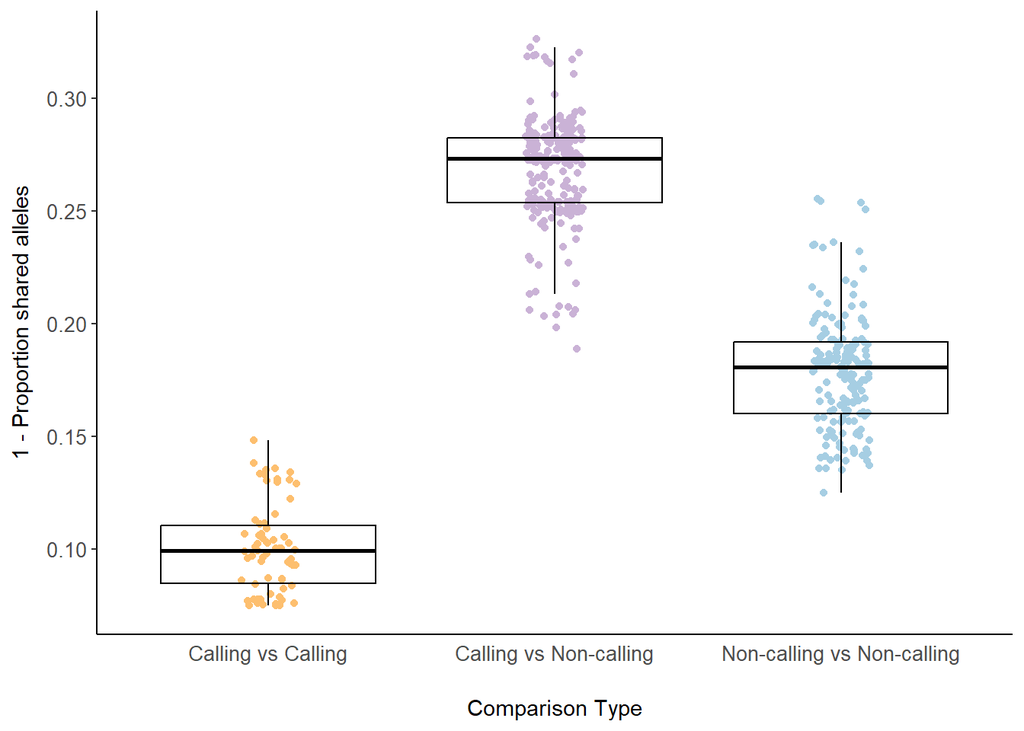

```r
## Saved with the mean point as one version and the boxplot as a second version

A_plot <- ggplot(data_subset, aes(x = Type, y = 1-Gen_dist, col = Type)) +
  geom_point(shape = 16, position = position_jitter(w=0.1, h=0)) +
  geom_boxplot(outlier.shape = NA, color = "black", fill = NA) +
  #stat_summary(fun = mean, geom = "point", size=2.5, color = "black") +
  scale_color_manual(values = c("Calling vs Non-calling"= "#CAB2D6", "Calling vs Calling" = "#FDBF6F", "Non-calling vs Non-calling"= "#A6CEE3")) +
  labs(y = "1 - Proportion shared alleles", x = "Comparison Type") +
  theme(legend.position = "none",
        axis.text.x = element_text(size=10),
        axis.text.y = element_text(size= 10),
        panel.background=element_rect(fill="white", color=NA),
        panel.grid.major = element_blank(),
        panel.grid.major.x = element_blank(),
        axis.line = element_line(color="black"),
        axis.ticks.x=element_blank(),
        axis.title.x = element_text(margin=margin(t=17)),
        axis.title.y = element_text (margin=margin(r=7), size=11))

A_plot
```

```r
ggsave(plot=A_plot, "C:/Users/jayna/OneDrive/Desktop/School/Lee_Yaw_Lab/Masters_Thesis/Data_chapter/RMD/IBD/Proportion_shared_alleles/IBD_ANOVA_allpts_boxplot.jpeg", dpi=800, width=8, height=8)
```

Randomizing one of the columns then taking the average genetic distance of each comparison type:

```r
# Create empty list
results_list <- list()

# Number of iterations
n_iterations <- 1000

for (i in 1:n_iterations) {
  ## Randomize the type column
  data_subset$Randomized_type <- sample(data_subset$Type)

  ## Run ANOVA
  anova_result <- aov(Gen_dist ~ Randomized_type, data = data_subset)
  anova_summary <- summary(anova_result)

  F_value <- anova_summary[[1]]$`F value`[1]
  P_value <- anova_summary[[1]]$`Pr(>F)`[1]

  ## group by type and calculate the mean of each type
  mean_results <- data_subset %>%
    group_by(Randomized_type) %>%
    summarise(mean_gendist = mean(Gen_dist)) %>%
    pivot_wider(names_from = Randomized_type, values_from = mean_gendist)

  ## Calculate differences between the means
  mean_results <- mean_results %>%
  mutate(diff_cvc_cvnc = `Calling vs Calling` - `Calling vs Non-calling`,
         diff_nvn_cvnc = `Non-calling vs Non-calling` - `Calling vs Non-calling`)

  ## Add additional columns to the new dataframe
  mean_results$F_value <- F_value
  mean_results$P_value <- P_value
  mean_results$Iteration <- i


  ## Store results
  results_list[[i]] <- mean_results

}

head(results_list[100])
```

```
## [[1]]
## # A tibble: 1 × 8
##   `Calling vs Calling` `Calling vs Non-calling` `Non-calling vs Non-calling`
##                  <dbl>                    <dbl>                        <dbl>
## 1                0.790                    0.788                        0.788
## # ℹ 5 more variables: diff_cvc_cvnc <dbl>, diff_nvn_cvnc <dbl>, F_value <dbl>,
## #   P_value <dbl>, Iteration <int>
```

```r
## Combine the different iterations
final_results <- do.call(rbind, results_list)

## Add on the real results
final_results <- rbind(final_results, real_results)

write.csv(final_results, "C:/Users/jayna/OneDrive/Desktop/School/Lee_Yaw_Lab/Masters_Thesis/Data_chapter/RMD/IBD/ANOVA_mean_results_differences.csv")
```

Make a histogram distribution of the means and where the real data mean is:

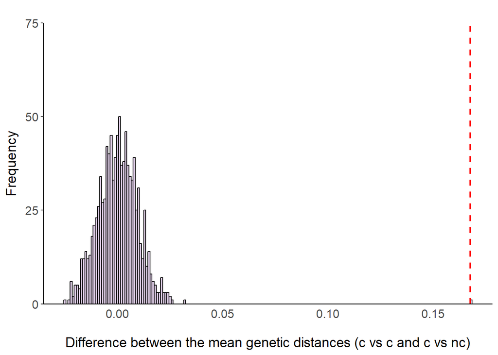

```r
##### Plot for calling vs calling and calling vs non-calling
## Sub set data
calling_calling <- final_results %>%
  select(diff_cvc_cvnc, Iteration)

## Setting the value to add the line of the "real data" point
Real_data_C <- "real data"
iteration_diffs_C <- calling_calling$diff_cvc_cvnc[calling_calling$Iteration == Real_data_C]


plot_hist1 <- ggplot(calling_calling, aes(x=diff_cvc_cvnc)) +
  geom_histogram(binwidth = 0.001, fill = "#CAB2D6", color = "black", alpha = 0.7) +
  geom_segment(aes(x = iteration_diffs_C, xend = iteration_diffs_C, y = 0, yend = 75), color = "red", linetype = "dashed", size = 0.8) +
  scale_y_continuous(expand = c(0,0), limits=c(0,75), breaks=seq(0, 75, by= 25)) +
  labs(title = " ", x = "Difference between the mean genetic distances (c vs c and c vs nc)", y = "Frequency") +
  theme(legend.position="none",
        axis.text.x = element_text(size=12),
        axis.text.y = element_text(size= 12),
        panel.background=element_rect(fill="white", color=NA),
        panel.grid.major = element_blank(),
        panel.grid.major.x = element_blank(),
        axis.line = element_line(color="black"),
        axis.ticks.x=element_blank(),
        axis.title.x = element_text(margin=margin(t=17), size=14),
        axis.title.y = element_text (margin=margin(r=7), size=14))
plot_hist1
```

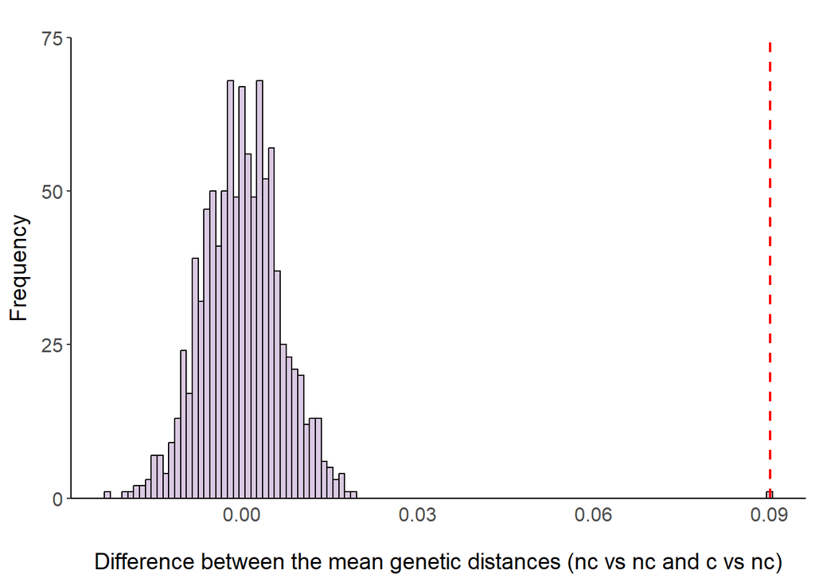

```r
ggsave(plot=plot_hist1, "C:/Users/jayna/OneDrive/Desktop/School/Lee_Yaw_Lab/Masters_Thesis/Data_chapter/RMD/IBD/calling_noncalling_mean_histogram_differences.jpeg", dpi=800, width=10, height=8)
##### Plot for noncalling vs noncalling and calling vs noncalling

## Subset data
noncalling_noncalling <- final_results %>%
  select(diff_nvn_cvnc, Iteration)

## Setting the value to add the line of the "real data" point
Real_data_NC <- "real data"
iteration_diffs_NC <- noncalling_noncalling$diff_nvn_cvnc[noncalling_noncalling$Iteration == Real_data_NC]


plot_hist2 <- ggplot(noncalling_noncalling, aes(x=diff_nvn_cvnc)) +
  geom_histogram(binwidth = 0.001, fill = "#CAB2D6", color = "black", alpha = 0.7) +
  geom_segment(aes(x = iteration_diffs_NC, xend = iteration_diffs_NC, y = 0, yend = 75), color = "red", linetype = "dashed", size = 0.8) +
  scale_y_continuous(expand = c(0,0), limits=c(0,75), breaks=seq(0, 75, by= 25)) +
  labs(title = " ", x = "Difference between the mean genetic distances (nc vs nc and c vs nc)", y = "Frequency") +
  theme(legend.position="none",
        axis.text.x = element_text(size=12),
        axis.text.y = element_text(size= 12),
        panel.background=element_rect(fill="white", color=NA),
        panel.grid.major = element_blank(),
        panel.grid.major.x = element_blank(),
        axis.line = element_line(color="black"),
        axis.ticks.x=element_blank(),
        axis.title.x = element_text(margin=margin(t=17), size=14),
        axis.title.y = element_text (margin=margin(r=7), size=14))


plot_hist2
```

```r
ggsave(plot=plot_hist2, "C:/Users/jayna/OneDrive/Desktop/School/Lee_Yaw_Lab/Masters_Thesis/Data_chapter/RMD/IBD/calling_calling_mean_histogram_differences.jpeg", dpi=800, width=10, height=8)
```

Make patchwork figure:

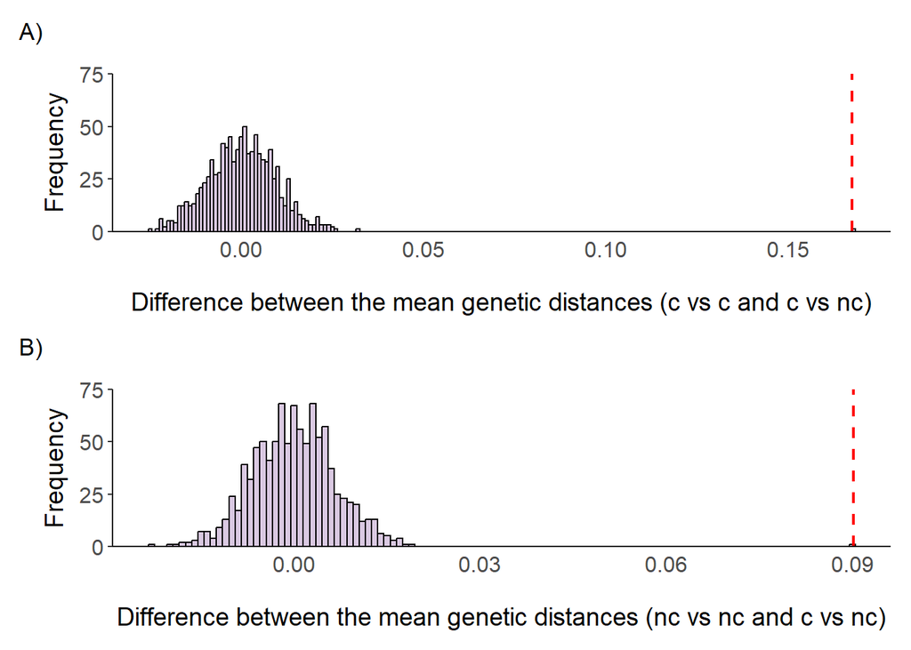

```r
Figure_allpts <- (plot_hist1) /
  (plot_hist2) +
  plot_annotation(tag_levels = 'A',
                  tag_suffix = ")")

Figure_allpts
```

```r
ggsave(plot=Figure_allpts, "C:/Users/jayna/OneDrive/Desktop/School/Lee_Yaw_Lab/Masters_Thesis/Data_chapter/RMD/IBD/All_points_mean_histogram_differences.jpeg", dpi=800, width=10, height=12)
```

### Conclusions

The differences between the means are statistically larger than expected by the null distribution.

### Specific notes for the manuscript/thesis

The first anova plot will go into the main manuscript and the histograms will go into the sup mat.